# optedr — Dossier de ejemplos

Diseño óptimo de experimentos para modelos no lineales

Carlos de la Calle-Arroyo

mayo 2026

```r
# devtools::install_github("Kezrael/optedr")   # primera vez
devtools::load_all()
# library(optedr)
```

Este dossier cubre el flujo de trabajo completo del paquete **optedr**: cálculo de diseños óptimos locales para modelos de regresión no lineal mediante el algoritmo cocktail (Yu, 2011), evaluación de eficiencia, aumento controlado de diseños y criterios compuestos. Los modelos unifactoriales usan `x` como variable de diseño; los multifactoriales usan `x1`, `x2`, … El paquete detecta la dimensión automáticamente a partir de la fórmula.

# 1 Diseño óptimo unifactorial

## 1.1 Criterios de optimalidad

El objeto devuelto por `opt_des()` es de clase `"optdes"` con componentes `$optdes` (tabla de puntos y pesos), `$criterion`, `$atwood` (cota Atwood, indicador de optimalidad), `$crit_value`, `$sens` y `$convergence`.

### 1.1.1 D-Optimality

Minimiza $\det(M^{-1})$, equivalente a minimizar el volumen del elipsoide de confianza de los parámetros.

```r
result_D <- opt_des(
  criterion    = "D-Optimality",
  model        = y ~ a * exp(-b / x),
  parameters   = c("a", "b"),
  par_values   = c(1, 1500),
  design_space = c(212, 422)
)
result_D
```

```
## Optimal design for D-Optimality:
##      Point    Weight
## 1 329.2963 0.5000089
## 2 422.0000 0.4999911
```

La función de sensibilidad $d(x, \xi^*) = f(x)^\top M^{-1} f(x)$ debe ser $\leq k$ en todo el espacio de diseño, con igualdad en los puntos de soporte (Teorema de Equivalencia de Kiefer–Wolfowitz). La cota de Atwood mide la proximidad a esta condición.

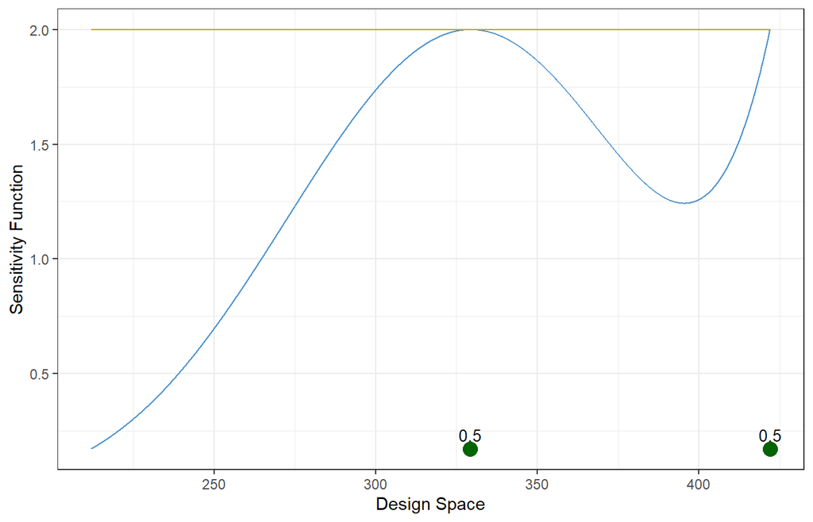

```r
plot(result_D)
```

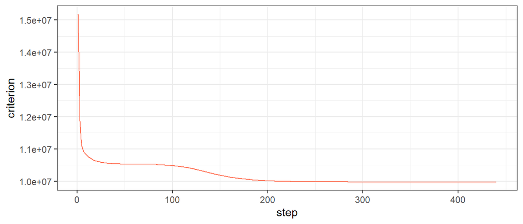

```r
plot(result_D$convergence)
```

### 1.1.2 Ds-Optimality

Enfoca la estimación en un subconjunto de parámetros indicado por `par_int`.

```r
result_Ds <- opt_des(
  criterion    = "Ds-Optimality",
  model        = y ~ th0 * exp(x / th1),
  parameters   = c("th0", "th1"),
  par_values   = c(10.4963, -3.2940),
  design_space = c(0.94, 30),
  par_int      = c(1)
)
result_Ds
```

```
## Optimal design for Ds-Optimality:
##      Point    Weight
## 1 0.940000 0.6042053
## 2 5.147919 0.3957947
```

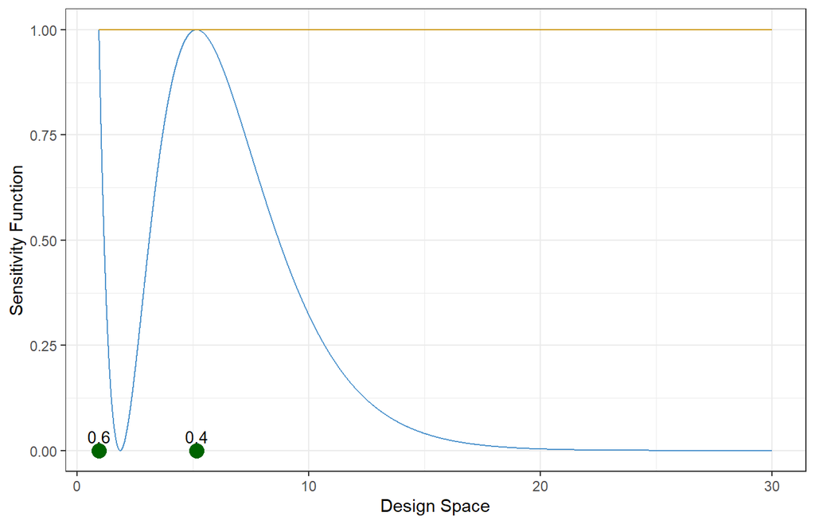

```r
plot(result_Ds)
```

### 1.1.3 I-Optimality

Minimiza la varianza integrada de predicción sobre una región de interés `reg_int` $\subseteq$ `design_space`.

```r
result_I <- opt_des(
  criterion    = "I-Optimality",
  model        = y ~ a * exp(-b / x),
  parameters   = c("a", "b"),
  par_values   = c(1, 1500),
  design_space = c(212, 422),
  reg_int      = c(380, 422)
)
result_I
```

```
## Optimal design for I-Optimality:
##     Point    Weight
## 1 357.518 0.4346119
## 2 422.000 0.5653881
```

### 1.1.4 A-Optimality

Minimiza $\text{tr}(M^{-1})$, el promedio de varianzas marginales.

```r
result_A <- opt_des(
  criterion    = "A-Optimality",
  model        = y ~ a * exp(-b / x),
  parameters   = c("a", "b"),
  par_values   = c(1, 1500),
  design_space = c(212, 422)
)
result_A
```

```
## Optimal design for A-Optimality:
##      Point    Weight
## 1 310.3784 0.7821613
## 2 422.0000 0.2178387
```

## 1.2 Eficiencia de diseños alternativos

La eficiencia compara un diseño propuesto $\xi$ con el óptimo $\xi^*$:
$$\text{eff}_D(\xi) = \left(\frac{\det M(\xi)}{\det
M(\xi^*)}\right)^{1/k}$$
Un valor del 70% significa que $\xi$ necesita $1/0.7 \approx 1.43$ veces más observaciones para igualar la precisión de $\xi^*$.

```r
design_ad_hoc <- data.frame(Point = c(220, 300, 400), Weight = rep(1/3, 3))
design_efficiency(design_ad_hoc, result_D)
```

```
## [1] 0.4734642
```

## 1.3 Control de convergencia

`max_iter` controla las iteraciones externas del algoritmo cocktail.

```r
r5  <- opt_des("D-Optimality", y ~ a*exp(-b/x), c("a","b"), c(1,1500),
               c(212,422), max_iter = 5L)
r50 <- opt_des("D-Optimality", y ~ a*exp(-b/x), c("a","b"), c(1,1500),
               c(212,422), max_iter = 50L)
cat("Atwood  5 iter:", r5$atwood,  "%\n")
```

```
## Atwood  5 iter: 99.99867 %
```

```r
cat("Atwood 50 iter:", r50$atwood, "%\n")
```

```
## Atwood 50 iter: 99.99879 %
```

## 1.4 Redondeo a diseños exactos

Los diseños aproximados asignan pesos continuos en $[0,1]$. Para obtener un diseño exacto de $n$ observaciones:

```r
# Método eficiente: multiplicador (n - l/2)
exact20 <- efficient_round(result_D$optdes, n = 20)
exact20
```

| Point | Weight |
| --- | --- |
| 329.2963 | 10 |
| 422.0000 | 10 |

```r
# Método combinatorial: busca la asignación floor/ceil óptima (O(2^k))
combo10 <- combinatorial_round(result_D, n = 10)
combo10
```

| Point | Weight |
| --- | --- |
| 329.2963 | 5 |
| 422.0000 | 5 |

## 1.5 Augment: añadir puntos con pérdida controlada

`get_augment_region()` calcula la región de puntos que garantizan que la eficiencia del diseño aumentado supere un umbral $\delta$. `augment_design()` añade el punto elegido y reescala los pesos según $\alpha$.

```r
init_des <- data.frame(Point = c(30, 60, 90), Weight = rep(1/3, 3))

region <- get_augment_region(
  criterion           = "D-Optimality",
  init_design         = init_des,
  alpha               = 0.25,
  model               = y ~ 10^(a - b/(c + x)),
  parameters          = c("a", "b", "c"),
  par_values          = c(8.07131, 1730.63, 233.426),
  design_space        = c(1, 100),
  calc_optimal_design = FALSE,
  delta_val           = 0.85
)
```

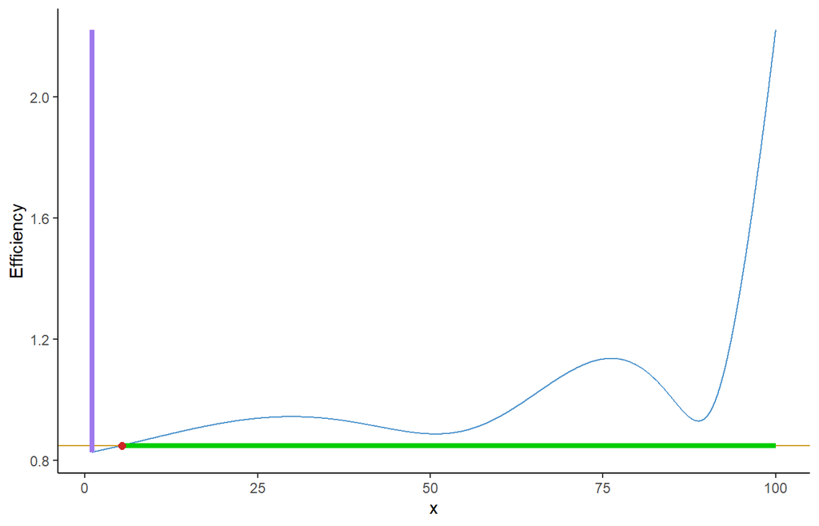

```r
region
```

```
## Augment candidate region  (delta = 0.8500)
##   Intervals: [5.361, 100]
```

```r
augmented <- augment_design(
  criterion           = "D-Optimality",
  init_design         = init_des,
  alpha               = 0.25,
  model               = y ~ 10^(a - b/(c + x)),
  parameters          = c("a", "b", "c"),
  par_values          = c(8.07131, 1730.63, 233.426),
  design_space        = c(1, 100),
  calc_optimal_design = TRUE,
  delta_val           = 0.85,
  new_points          = data.frame(Point = mean(region$region[1:2]), Weight = 1)
)
```

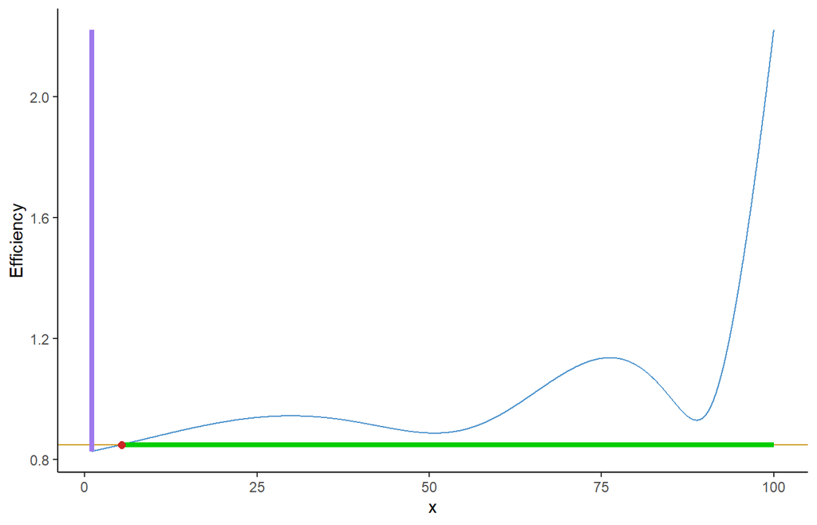

```r
augmented
```

| Point | Weight |
| --- | --- |
| 30.00000 | 0.25 |
| 60.00000 | 0.25 |
| 90.00000 | 0.25 |
| 52.68026 | 0.25 |

> **Uso interactivo:** omitir `delta_val` y `new_points`. El paquete pregunta el umbral, muestra la región candidata y solicita coordenadas en la consola.

## 1.6 Identificabilidad de parámetros

Cuando los parámetros no son identificables, $M$ es (casi) singular. `inv_spd()` usa pseudoinversa y advierte sobre el número de parámetros no identificables.

```r
# Modelo BET: 3 parámetros, pero solo 2 son identificables conjuntamente.
# inv_spd() usa pseudoinversa con advertencia; update_weights() detiene
# el algoritmo cuando los pesos se vuelven no finitos.
tryCatch(
  opt_des(
    criterion    = "D-Optimality",
    model        = y ~ (w*c*k*x) / ((1-x) * (1 + (c-1)*k*x)),
    parameters   = c("w", "c", "k"),
    par_values   = c(1, 10, 0.5),
    design_space = c(0.05, 0.8)
  ),
  error = function(e)
    cat("Error esperado (no-identificabilidad):\n  ", conditionMessage(e), "\n")
)
```

```
## Error esperado (no-identificabilidad):
##    Weight update produced non-finite values. The model is likely not identifiable in all specified parameters -check for parameter redundancy (see warnings above).
```

```r
# Modelo reparametrizado con 2 parámetros identificables: converge correctamente
result_repar <- opt_des(
  criterion    = "D-Optimality",
  model        = y ~ (a * x) / ((1 - x) * (1 + b * x)),
  parameters   = c("a", "b"),
  par_values   = c(5, 4.5),
  design_space = c(0.05, 0.8)
)
result_repar
```

```
## Optimal design for D-Optimality:
##       Point    Weight
## 1 0.1903882 0.4999936
## 2 0.8000000 0.5000064
```

# 2 Diseño óptimo multifactorial — d = 2

Para modelos con dos variables de diseño `x1`, `x2`, el espacio se especifica como `list(x1 = c(min, max), x2 = c(min, max))`. `plot()` devuelve un **heatmap** viridis de la función de sensibilidad compuesta con el contorno del Teorema de Equivalencia (línea blanca) y los puntos de soporte etiquetados.

## 2.1 D-Optimality 2D — bisubstrato Michaelis-Menten

$$y = \frac{V_{\max} \cdot x_1 \cdot
x_2}{(K_1 + x_1)(K_2 + x_2)}$$

```r
result_2D <- opt_des(
  criterion    = "D-Optimality",
  model        = y ~ Vmax * x1 * x2 / ((K1 + x1) * (K2 + x2)),
  parameters   = c("Vmax", "K1", "K2"),
  par_values   = c(1, 1, 1),
  design_space = list(x1 = c(0.1, 10), x2 = c(0.1, 10))
)
result_2D
```

```
## Optimal design for D-Optimality (2 factors):
##           x1         x2    Weight
## 1  0.8329942 10.0000000 0.3333291
## 2  9.9998373  9.9998126 0.3333418
## 3 10.0000000  0.8329319 0.3333291
```

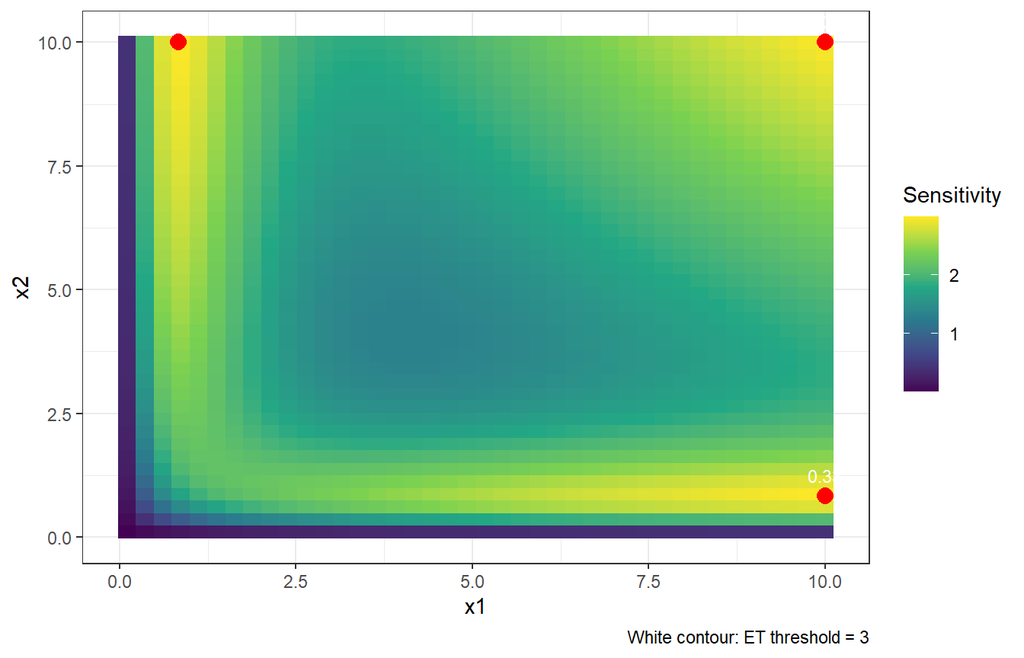

```r
plot(result_2D)
```

## 2.2 A-Optimality 2D

```r
result_2D_A <- opt_des(
  criterion    = "A-Optimality",
  model        = y ~ Vmax * x1 * x2 / ((K1 + x1) * (K2 + x2)),
  parameters   = c("Vmax", "K1", "K2"),
  par_values   = c(1, 1, 1),
  design_space = list(x1 = c(0.1, 10), x2 = c(0.1, 10))
)
result_2D_A
```

```
## Optimal design for A-Optimality (2 factors):
##           x1         x2    Weight
## 1  0.6585237  9.9999176 0.3724145
## 2  9.9998487  0.6571287 0.3725222
## 3 10.0000000 10.0000000 0.2550633
```

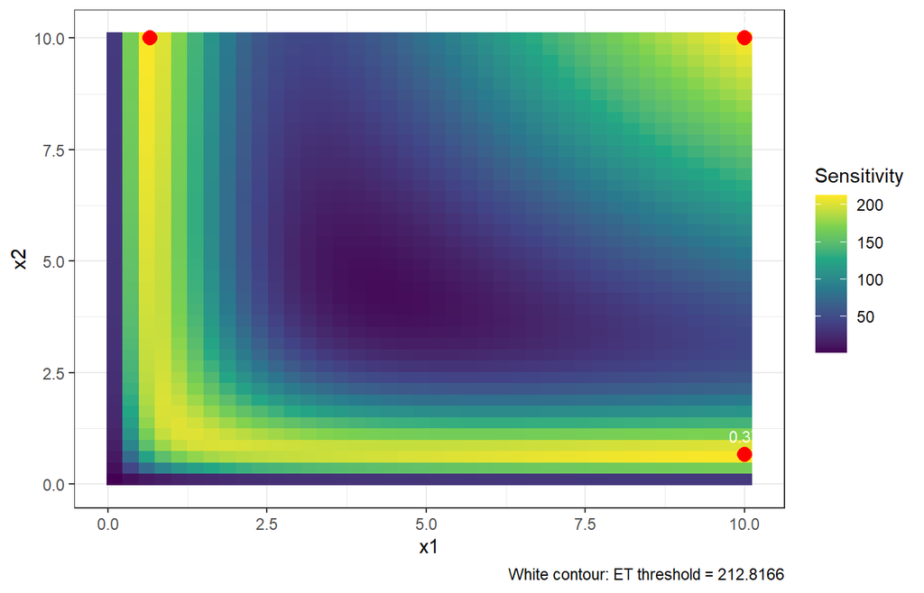

```r
plot(result_2D_A)
```

## 2.3 I-Optimality 2D con región de interés

`reg_int` se pasa como lista nombrada. La matriz $B$ se calcula por integración Monte Carlo (LHS, 10 000 puntos) sobre la región de interés.

```r
result_2D_I <- opt_des(
  criterion    = "I-Optimality",
  model        = y ~ Vmax * x1 * x2 / ((K1 + x1) * (K2 + x2)),
  parameters   = c("Vmax", "K1", "K2"),
  par_values   = c(1, 1, 1),
  design_space = list(x1 = c(0.1, 10), x2 = c(0.1, 10)),
  reg_int      = list(x1 = c(1, 5),   x2 = c(1, 5))
)
result_2D_I
```

```
## Optimal design for I-Optimality (2 factors):
##          x1        x2    Weight
## 1  1.073085 10.000000 0.2914309
## 2  1.785473  1.784890 0.2358448
## 3 10.000000 10.000000 0.1813028
## 4 10.000000  1.073778 0.2914216
```

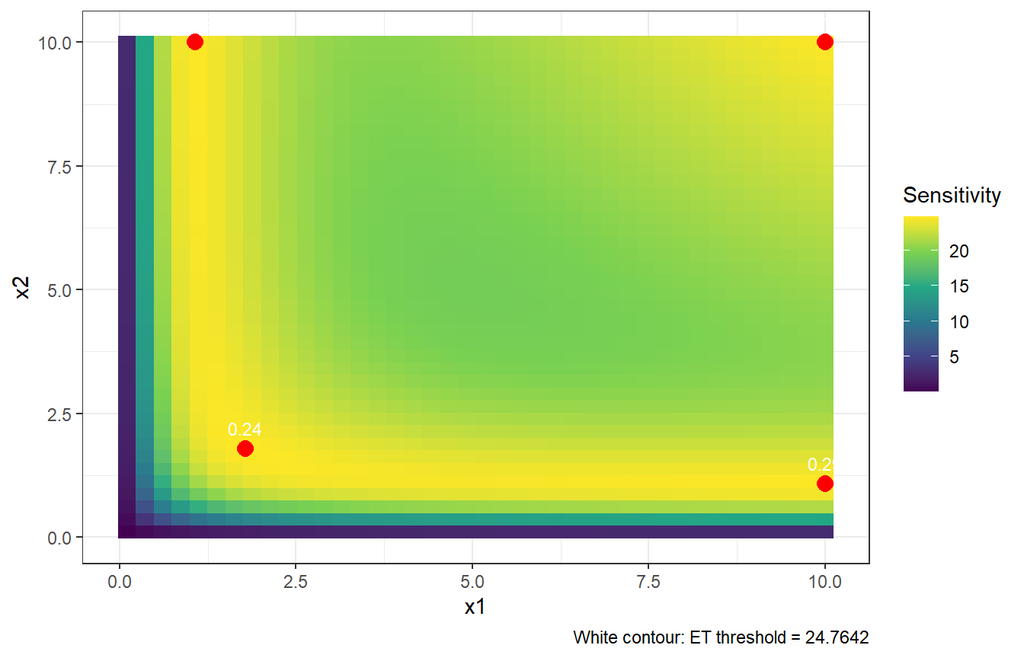

```r
plot(result_2D_I)
```

## 2.4 Eficiencia en 2D

```r
corners_2d <- data.frame(
  x1 = c(0.1,10,0.1,10), x2 = c(0.1,0.1,10,10), Weight = rep(0.25,4))
eff_2d <- design_efficiency(corners_2d, result_2D)
cat("Eficiencia 4 esquinas:", round(eff_2d*100, 2), "%\n")
```

```
## Eficiencia 4 esquinas: 19.34 %
```

## 2.5 Augment 2D — heatmap de la región candidata

```r
init_2d <- data.frame(x1=c(0.8,10,5), x2=c(10,0.8,5), Weight=rep(1/3,3))

region_2d <- get_augment_region(
  criterion           = "D-Optimality",
  init_design         = init_2d,
  alpha               = 0.25,
  model               = y ~ Vmax * x1 * x2 / ((K1 + x1) * (K2 + x2)),
  parameters          = c("Vmax", "K1", "K2"),
  par_values          = c(1, 1, 1),
  design_space        = list(x1 = c(0.1, 10), x2 = c(0.1, 10)),
  calc_optimal_design = FALSE,
  delta_val           = 0.85
)
```

```r
region_2d
```

```
## Augment candidate region  (delta = 0.8500)
##   1907 candidate points  (2 factors)
##   Efficiency range: [0.8500, 1.2437]
```

```r
plot(region_2d$plot)
```

[output not shown]

```r
best_2d <- region_2d$region[which.max(region_2d$region$efficiency), ]
aug_2d  <- augment_design(
  criterion           = "D-Optimality",
  init_design         = init_2d,
  alpha               = 0.25,
  model               = y ~ Vmax * x1 * x2 / ((K1 + x1) * (K2 + x2)),
  parameters          = c("Vmax", "K1", "K2"),
  par_values          = c(1, 1, 1),
  design_space        = list(x1 = c(0.1, 10), x2 = c(0.1, 10)),
  calc_optimal_design = TRUE,
  delta_val           = 0.85,
  new_points          = data.frame(x1=best_2d$x1, x2=best_2d$x2, Weight=1)
)
```

```
## Sample of candidate points:
##           x1        x2 efficiency
## 1  3.7994912 0.3034668  0.8890888
## 2  9.6471393 9.0628996  1.2196254
## 3  1.1496945 2.8263243  0.9234808
## 4  5.0746362 8.4078643  1.0516899
## 5  4.9695184 9.5867891  1.0707730
## 6  4.9479514 6.3322055  0.9895899
## 7  8.5856580 5.4454027  1.0734720
## 8  5.0283144 4.8209796  0.9390535
## 9  8.3481442 4.3781097  1.0139295
## 10 9.6353910 4.0413749  1.0189368
## 11 8.7184965 0.3469133  0.9109116
## 12 3.4962914 9.5968059  0.9841679
## 13 0.6500368 2.9238895  0.9423782
## 14 1.9441756 2.9890263  0.8677770
## 15 5.2035061 6.7561326  1.0141693
```

```r
aug_2d
```

| x1 | x2 | Weight |
| --- | --- | --- |
| 0.800000 | 10.000000 | 0.25 |
| 10.000000 | 0.800000 | 0.25 |
| 5.000000 | 5.000000 | 0.25 |
| 9.970639 | 9.821602 | 0.25 |

# 3 Diseño óptimo multifactorial — d ≥ 3

Para $d > 2$ no existe heatmap de sensibilidad. `plot()` devuelve un **scatter matrix** con $\binom{d}{2}$ paneles “xi vs xj”, con tamaño de punto proporcional al peso en escala absoluta $[0,1]$. `get_augment_region()` muestra un scatter análogo coloreando candidatos (azul), no-candidatos (gris) y diseño actual (triángulos rojos).

## 3.1 D-Optimality 3D — trisubstrato Michaelis-Menten

$$y = \frac{V_{\max} \cdot x_1 x_2
x_3}{(K_1+x_1)(K_2+x_2)(K_3+x_3)}$$

Con $k=4$ parámetros el diseño óptimo tiene al menos 4 puntos de soporte. $\binom{3}{2} = 3$ paneles: $x_1$ vs $x_2$, $x_1$ vs $x_3$, $x_2$ vs $x_3$.

```r
result_3D <- opt_des(
  criterion    = "D-Optimality",
  model        = y ~ Vmax*x1*x2*x3/((K1+x1)*(K2+x2)*(K3+x3)),
  parameters   = c("Vmax","K1","K2","K3"),
  par_values   = c(1,1,1,1),
  design_space = list(x1=c(0.1,10), x2=c(0.1,10), x3=c(0.1,10))
)
result_3D
```

```
## Optimal design for D-Optimality (3 factors):
##         x1         x2         x3    Weight
## 1  0.83432 10.0000000 10.0000000 0.2499980
## 2 10.00000  0.8345708 10.0000000 0.2499979
## 3 10.00000 10.0000000  0.8326156 0.2500062
## 4 10.00000 10.0000000 10.0000000 0.2499979
```

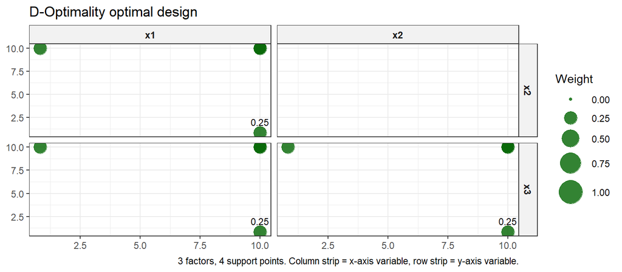

```r
plot(result_3D)
```

```r
corners_3d        <- expand.grid(x1=c(0.1,10), x2=c(0.1,10), x3=c(0.1,10))
corners_3d$Weight <- rep(1/8, 8)
eff_3d <- design_efficiency(corners_3d, result_3D)
cat("Eficiencia 8 esquinas:", round(eff_3d*100, 2),
    "% — el óptimo concentra los puntos de forma muy específica\n")
```

```
## Eficiencia 8 esquinas: 10.96 % — el óptimo concentra los puntos de forma muy específica
```

## 3.2 Augment 3D — scatter matrix de candidatos

El diseño inicial necesita $\geq k+1 = 5$ puntos en esquinas para que $M$ sea no singular.

```r
init_3d_aug <- data.frame(
  x1 = c(0.8,10,10,0.8,10), x2 = c(10,0.8,10,10,0.8),
  x3 = c(10,10,0.8,0.8,10), Weight = rep(0.2,5)
)

region_3d <- get_augment_region(
  criterion           = "D-Optimality",
  init_design         = init_3d_aug,
  alpha               = 0.45,
  model               = y ~ Vmax*x1*x2*x3/((K1+x1)*(K2+x2)*(K3+x3)),
  parameters          = c("Vmax","K1","K2","K3"),
  par_values          = c(1,1,1,1),
  design_space        = list(x1=c(0.1,10), x2=c(0.1,10), x3=c(0.1,10)),
  calc_optimal_design = FALSE,
  delta_val           = 0.93
)
```

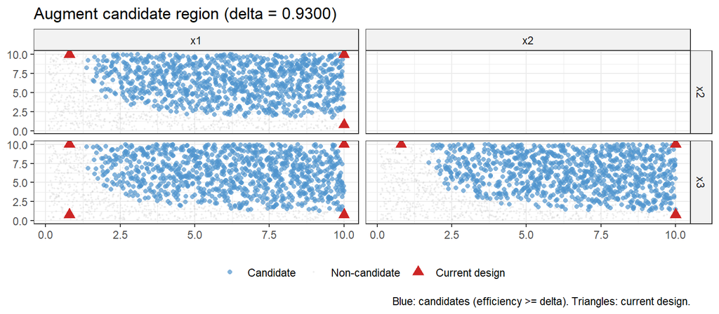

```r
region_3d
```

```
## Augment candidate region  (delta = 0.9300)
##   950 candidate points  (3 factors)
##   Efficiency range: [0.9312, 1.7293]
```

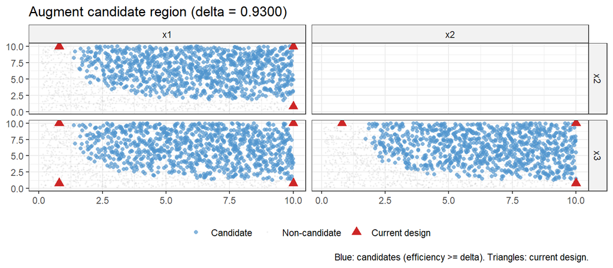

```r
plot(region_3d$plot)
```

## 3.3 D-Optimality 4D — modelo lineal

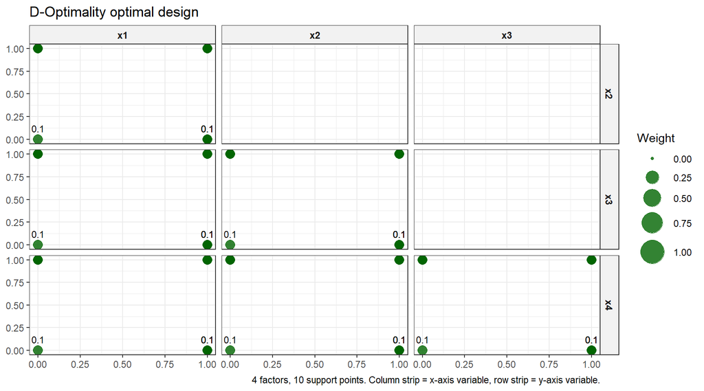

```r
result_4D <- opt_des(
  criterion    = "D-Optimality",
  model        = y ~ a*x1 + b*x2 + c*x3 + d*x4,
  parameters   = c("a","b","c","d"),
  par_values   = c(1,1,1,1),
  design_space = list(x1=c(0,1), x2=c(0,1), x3=c(0,1), x4=c(0,1))
)
plot(result_4D)
```

# 4 Criterios compuestos

`criterion = "Compound"` combina criterios individuales como suma ponderada de sus funciones de sensibilidad:
$$d_c(x) = \sum_i w_i \, d_i(x), \qquad \sum_i w_i
= 1$$

El Teorema de Equivalencia se preserva (la combinación convexa de funciones convexas es convexa) y el algoritmo cocktail converge de la misma forma que para criterios individuales. Los pesos se normalizan automáticamente.

```yaml
compound = list(
  list(criterion = "D-Optimality", weight = 0.7),
  list(criterion = "I-Optimality", weight = 0.3, reg_int = c(60, 100))
)
```

## 4.1 D + I (70/30) — Antoine 1D

D asegura buena estimación global de los 3 parámetros; I concentra precisión en la región operativa $[60, 100]$.

```r
result_DI <- opt_des(
  criterion    = "Compound",
  model        = y ~ 10^(a - b / (c + x)),
  parameters   = c("a", "b", "c"),
  par_values   = c(8.07131, 1730.63, 233.426),
  design_space = c(1, 100),
  compound     = list(
    list(criterion = "D-Optimality", weight = 0.7),
    list(criterion = "I-Optimality", weight = 0.3, reg_int = c(60, 100))
  )
)
result_DI
```

```
## Optimal design for Compound (0.70*D + 0.30*I):
##       Point    Weight
## 1  46.50267 0.3047727
## 2  82.87444 0.4062833
## 3 100.00000 0.2889441
```

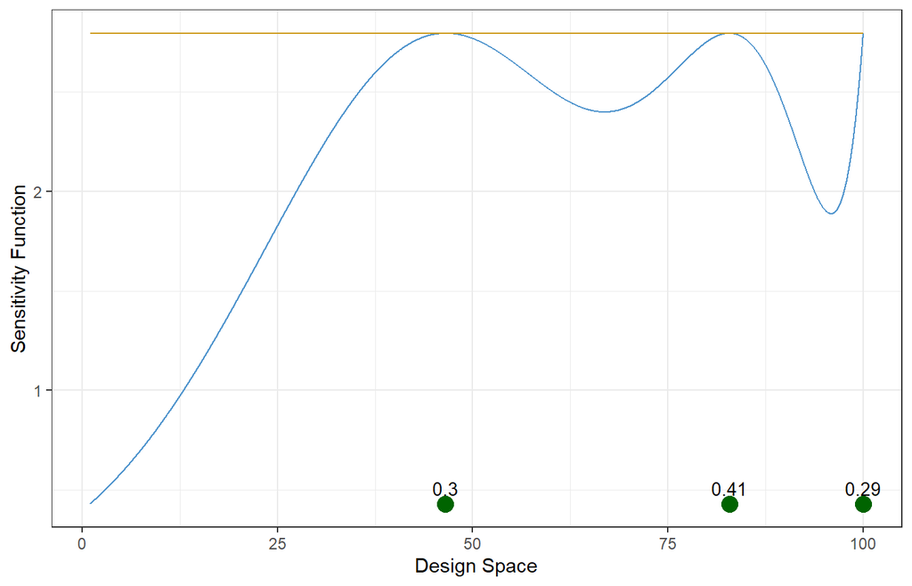

```r
plot(result_DI)
```

Comparación con el D-óptimo puro:

```r
result_D_ant <- opt_des("D-Optimality", y~10^(a-b/(c+x)),
                        c("a","b","c"), c(8.07131,1730.63,233.426), c(1,100))
cat("D-óptimo puro:\n");        print(result_D_ant)
```

```
## D-óptimo puro:
```

```
## Optimal design for D-Optimality:
##       Point    Weight
## 1  44.90080 0.3333415
## 2  83.19032 0.3333292
## 3 100.00000 0.3333293
```

```r
cat("D+I compuesto (70/30):\n"); print(result_DI)
```

```
## D+I compuesto (70/30):
```

```
## Optimal design for Compound (0.70*D + 0.30*I):
##       Point    Weight
## 1  46.50267 0.3047727
## 2  82.87444 0.4062833
## 3 100.00000 0.2889441
```

```r
cat("Eficiencia D del compuesto vs D-puro:\n")
```

```
## Eficiencia D del compuesto vs D-puro:
```

```r
design_efficiency(result_DI,    result_D_ant)
```

```
## [1] 0.9869661
```

```r
cat("Eficiencia compuesta del D-puro vs compuesto:\n")
```

```
## Eficiencia compuesta del D-puro vs compuesto:
```

```r
design_efficiency(result_D_ant, result_DI)
```

```
## [1] 0.9314727
```

## 4.2 D + A (50/50)

`summary()` muestra la composición del criterio.

```r
result_DA <- opt_des(
  criterion    = "Compound",
  model        = y ~ a * exp(-b / x),
  parameters   = c("a", "b"),
  par_values   = c(1, 1500),
  design_space = c(212, 422),
  compound     = list(
    list(criterion = "D-Optimality", weight = 0.5),
    list(criterion = "A-Optimality", weight = 0.5)
  )
)
summary(result_DA)
```

```
## Model:
## y ~ a * exp(-b/x)
## Weight function:
## function(x) 1
##
## Compound criterion:
##   0.50 * D-Optimality
##   0.50 * A-Optimality
##
## Optimal design for Compound:
##      Point    Weight
## 1 310.3784 0.7821613
## 2 422.0000 0.2178387
##
## Minimum efficiency (Atwood): 99.9999982911667%
## Criterion value:             1.77488e+10
```

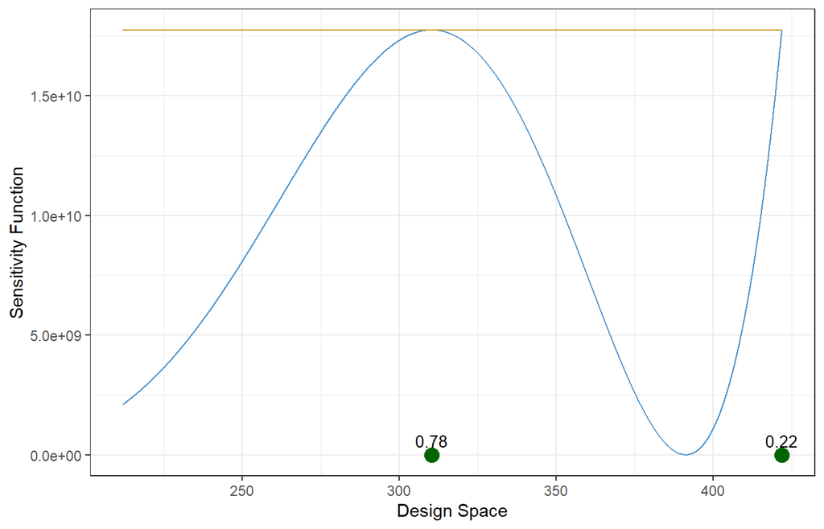

```r
plot(result_DA)
```

## 4.3 D + A + I tres componentes (bisubstrato 2D)

El heatmap muestra la función de sensibilidad compuesta $d_c = 0.5\,d_D + 0.25\,d_A + 0.25\,d_I$.

```r
result_DAI <- opt_des(
  criterion    = "Compound",
  model        = y ~ Vmax * x1 * x2 / ((K1+x1) * (K2+x2)),
  parameters   = c("Vmax", "K1", "K2"),
  par_values   = c(1, 1, 1),
  design_space = list(x1 = c(0.1,10), x2 = c(0.1,10)),
  compound     = list(
    list(criterion = "D-Optimality", weight = 0.50),
    list(criterion = "A-Optimality", weight = 0.25),
    list(criterion = "I-Optimality", weight = 0.25,
         reg_int = list(x1=c(1,5), x2=c(1,5)))
  )
)
result_DAI
```

```
## Optimal design for Compound (0.50*D + 0.25*A + 0.25*I):
##           x1         x2    Weight
## 1  0.7446877 10.0000000 0.3686722
## 2 10.0000000  0.7823553 0.3677042
## 3 10.0000000 10.0000000 0.2636236
```

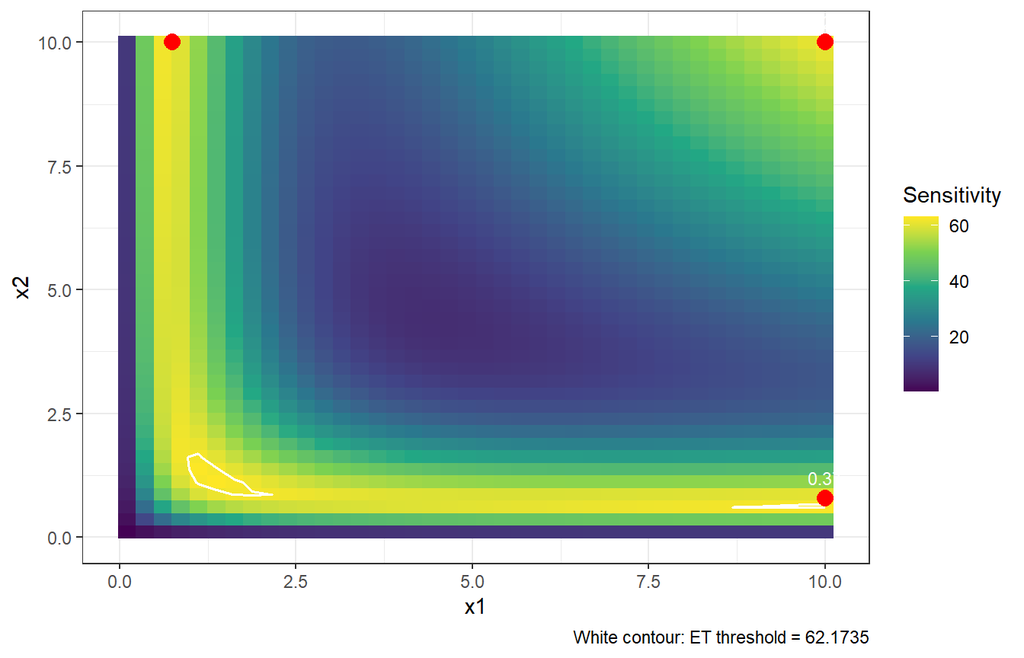

```r
plot(result_DAI)
```

# 5 KL-Optimality — discriminación entre modelos

El criterio **KL-Optimality** (López-Fidalgo, Tommasi & Trandafir, 2007) maximiza la divergencia de Kullback-Leibler integrada entre el modelo de referencia $f_1$ (parámetros nominales $\boldsymbol\beta_1$ conocidos) y el rival más adversario $f_2$ (parámetros $\boldsymbol\beta_2$ libres):
$$I_{2,1}(\xi) = \min_{\boldsymbol\beta_2}
\int_\mathcal{X}
\mathrm{KL}\bigl(f_1(\cdot\mid x,\boldsymbol\beta_1) \,\|\,
f_2(\cdot\mid
x,\boldsymbol\beta_2)\bigr)\,\xi(dx)$$

Para familias exponenciales con función cumulante $b(\cdot)$ y dispersión $\phi$:
$$\mathrm{KL}(x,\boldsymbol\mu_1,\boldsymbol\mu_2)
=
\frac{1}{\phi}\bigl[b(\theta_2)-b(\theta_1)-(\theta_2-\theta_1)\,b'(\theta_1)\bigr]$$

El algoritmo cocktail **maximiza** $I_{2,1}$ con un paso externo de vertex-direction y resuelve la minimización interna con `stats::optim` (BFGS / L-BFGS-B).

## 5.1 Vía estándar — rival con estructura de media distinta (Normal, 1D)

El camino clásico pasa los argumentos `rival_model`, `rival_params`, `family` y `phi` directamente a `opt_des()`. El paquete construye automáticamente la función KL usando la fórmula cumulante.

```r
# Michaelis-Menten vs lineal: acotamos a ∈ [0.2, 2.5] para evitar KL ≈ 0
result_kl_mm <- opt_des(
  "KL-Optimality",
  model        = y ~ Vmax * x / (Km + x),
  parameters   = c("Vmax", "Km"),
  par_values   = c(2, 1),
  design_space = c(0.1, 5),
  rival_model  = y ~ a * x,
  rival_params = c("a"),
  rival_pars   = c(1),
  rival_lower  = c(0.2),
  rival_upper  = c(2.5),
  family       = "Normal",
  phi          = 1
)
result_kl_mm
```

```
## Optimal design for KL-Optimality:
##      Point    Weight
## 1 1.127578 0.8159831
## 2 5.000000 0.1840169
```

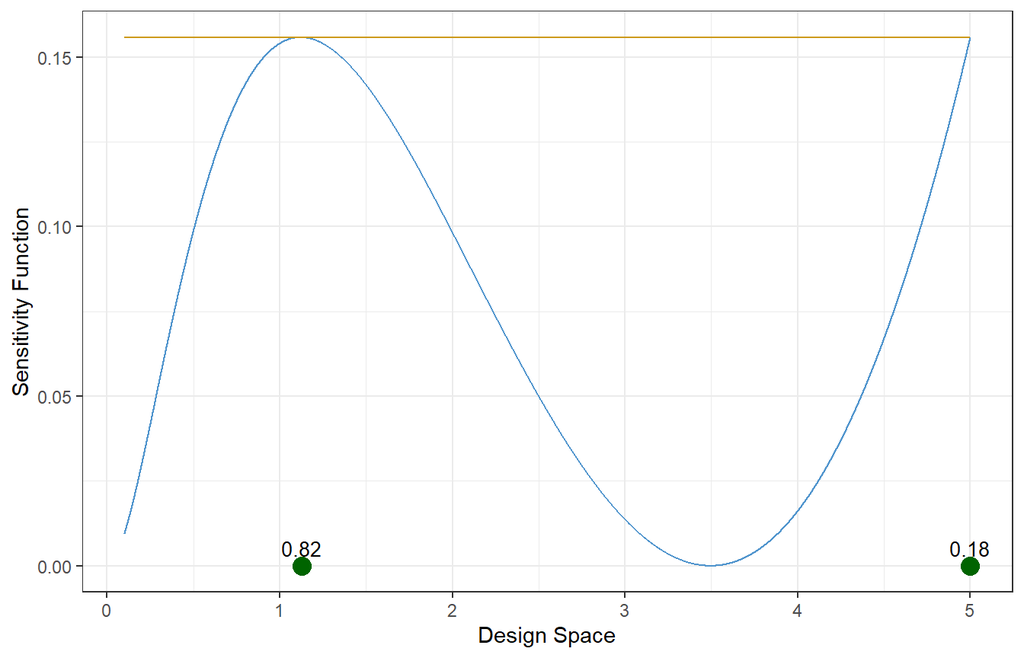

```r
plot(result_kl_mm)
```

```r
# Eficiencia de un diseño uniforme de 5 puntos
des_unif5 <- data.frame(Point = seq(0.1, 5, length.out = 5), Weight = rep(1/5, 5))
design_efficiency(des_unif5, result_kl_mm)
```

```
## [1] 0.4343391
```

## 5.2 `make_kl_fun` — función KL generada automáticamente

`make_kl_fun()` construye la clausura `kl_fun(x, beta2)` para los pares de familias soportados, incluyendo Normal con distinta dispersión y Gamma con distinta forma. El resultado se pasa a `opt_des()` via el argumento `kl_fun`.

**Normal($\phi_1=1$) vs Normal($\phi_2=4$) — discriminar media y varianza**

$$\mathrm{KL} =
\tfrac{1}{2}\!\left[\log\!\frac{\phi_2}{\phi_1}+\frac{\phi_1}{\phi_2}+\frac{(\mu_1-\mu_2)^2}{\phi_2}-1\right]$$

```r
kl_fn_var <- make_kl_fun(
  "Normal",
  model1 = y ~ a * exp(-b * x), params1 = c("a", "b"),
  par_values1 = c(1, 0.5), phi1 = 1,
  family2 = "Normal",
  model2  = y ~ c * exp(-d * x), params2 = c("c", "d"), phi2 = 4
)

result_kl_var <- opt_des(
  "KL-Optimality",
  model        = y ~ a * exp(-b * x),
  parameters   = c("a", "b"),
  par_values   = c(1, 0.5),
  design_space = c(0, 4),
  kl_fun       = kl_fn_var,
  rival_pars   = c(1, 1.0),
  rival_lower  = c(0.5, 0.8),
  rival_upper  = c(2.0, 1.5)
)
result_kl_var
```

```
## Optimal design for KL-Optimality:
##      Point     Weight
## 1 0.000000 0.16826906
## 2 1.333333 0.07912872
## 3 1.989481 0.61240029
## 4 2.666667 0.14020193
```

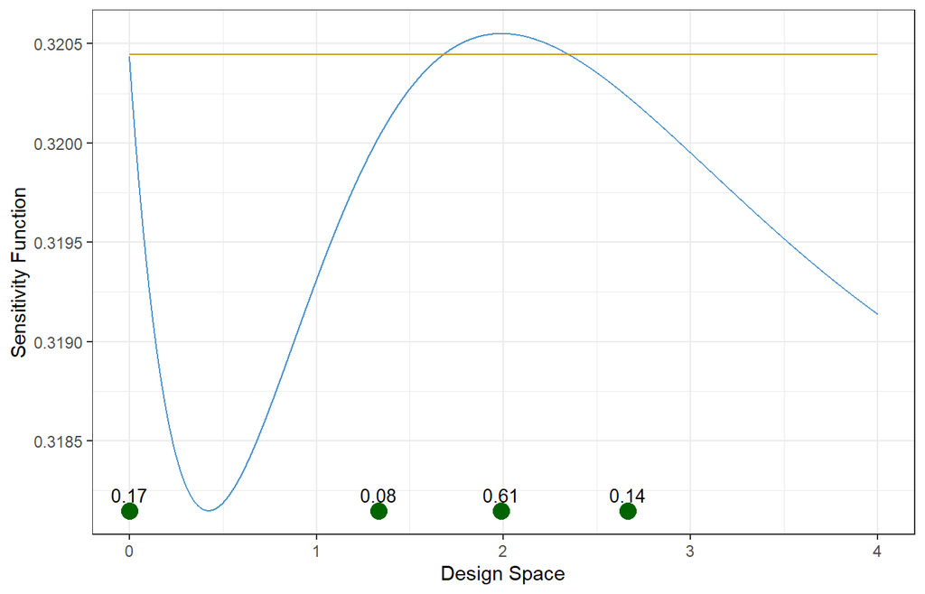

```r
plot(result_kl_var)
```

## 5.3 Modelo Hill — error absoluto vs relativo (de la Calle-Arroyo et al., 2025)

> De la Calle-Arroyo, Leorato, Rodríguez-Aragón & Tommasi (2025). *Augmented designs to choose between constant absolute and relative errors and to estimate model parameters.* **Chemometrics and Intelligent Laboratory Systems**, pii S0169743925000474.

**Modelo Hill de 4 parámetros** (dosis-respuesta / cinética de Emax):
$$\eta(x,\boldsymbol\beta)
= \frac{(E_{con}-b)\,(x/IC_{50})^s}{1+(x/IC_{50})^s}+b,
\quad \boldsymbol\beta=(1.70,\,0.137,\,111,\,-1.03),\quad
x\in[0.01,1500]$$

Se discrimina entre:

|  | Distribución | Varianza |
| --- | --- | --- |
| $f_1$ (referencia) | $\mathcal{N}(\eta,\,c_v^2\eta^2)$ | error relativo constante |
| $f_2$ (rival) | $\mathcal{N}(\eta,\,\sigma^2)$ | error absoluto constante |

La KL integrada minimizada sobre $\sigma^2$ admite fórmula cerrada:
$$I_{2,1}(\xi)=\tfrac{1}{2}\bigl[\log\mathbb{E}_\xi[\eta^2]-2\,\mathbb{E}_\xi[\log\eta]\bigr]
\quad\text{(AM–GM sobre }\eta^2\text{)}$$
con mínimo alcanzado en $\sigma^{2*}=\mathbb{E}_\xi[\eta^2]$.

```r
# KL(N(eta, eta^2) || N(eta, sigma_sq)), rival param = sigma_sq
kl_fun_hill <- function(x, beta2) {
  sigma_sq <- beta2[1]
  eta <- (1.70 - 0.137) * (x / 111)^(-1.03) / (1 + (x / 111)^(-1.03)) + 0.137
  0.5 * (eta^2 / sigma_sq - 1 + log(sigma_sq / eta^2))
}

result_kl_hill <- opt_des(
  "KL-Optimality",
  model        = y ~ (Econ - b) * (x / IC50)^s / (1 + (x / IC50)^s) + b,
  parameters   = c("Econ", "b", "IC50", "s"),
  par_values   = c(1.70, 0.137, 111, -1.03),
  design_space = c(0.01, 1500),
  kl_fun       = kl_fun_hill,
  rival_pars   = c(1.0),
  rival_lower  = c(1e-4),
  rival_upper  = c(1e6)
)
result_kl_hill
```

```
## Optimal design for KL-Optimality:
##     Point   Weight
## 1    0.01 0.233994
## 2 1500.00 0.766006
```

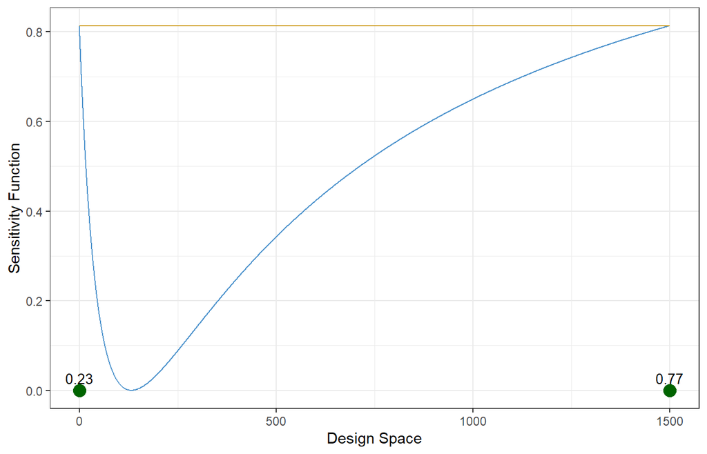

```r
plot(result_kl_hill)
```

```r
hv <- attr(result_kl_hill, "hidden_value")
cat("Rival optimo sigma_abs^2 =", round(hv$beta2_star, 4), "\n")
```

```
## Rival optimo sigma_abs^2 = 0.7192
```

```r
cat("Resultado del paper:  {0.01 -> 0.23, 1500 -> 0.77}\n")
```

```
## Resultado del paper:  {0.01 -> 0.23, 1500 -> 0.77}
```

```r
cat("Atwood:", result_kl_hill$atwood, "% — diseno exactamente optimo\n")
```

```
## Atwood: 99.99972 % — diseno exactamente optimo
```

```r
# KL-eficiencia de un diseno uniforme
des_unif_hill <- data.frame(
  Point = c(0.01, 375, 750, 1125, 1500), Weight = rep(1/5, 5))
design_efficiency(des_unif_hill, result_kl_hill)
```

```
## [1] 0.75417
```

El diseño KL-óptimo tiene sólo 2 puntos de soporte: no puede estimar los 4 parámetros de la Hill. El paper propone el *diseño KL-aumentado*, que añade puntos del D-óptimo garantizando una eficiencia KL mínima.

# 6 Caso de estudio — Ecuación de Tait para datos pVT

> Martín-Martín, Rodríguez-Aragón & Torsney (2012). *Multiplicative algorithm for computing D-optimum designs for pVT measurements.* Chemometrics and Intelligent Laboratory Systems **111**, 20–27.

La ecuación de Tait describe la densidad de líquidos en función de presión $p$ y temperatura $T$:
$$\rho(p,T)
= \rho_0(T)\!\left[1 - C\ln\!\frac{B(T)+p}{B(T)+p_0}\right]$$

Los tres ejemplos del paper se replican directamente con optedr.

## 6.1 Tait isoterma — clorodifluorometano (1D, $k=3$)

$V(p) = V_0[1 - C\ln((B+p)/(B+p_0))]$, $p_0 = 10$ MPa. El paper obtiene 3 puntos en $\{10, 66.5, 500\}$ MPa con pesos $1/3$.

```r
result_tait1 <- opt_des(
  criterion    = "D-Optimality",
  model        = y ~ V0 * (1 - C * log((B + x) / (B + 10))),
  parameters   = c("V0", "B", "C"),
  par_values   = c(0.815, 16.81, 0.0982),
  design_space = c(10, 500)
)
result_tait1
```

```
## Optimal design for D-Optimality:
##       Point    Weight
## 1  10.00000 0.3333305
## 2  67.10382 0.3333390
## 3 500.00000 0.3333305
```

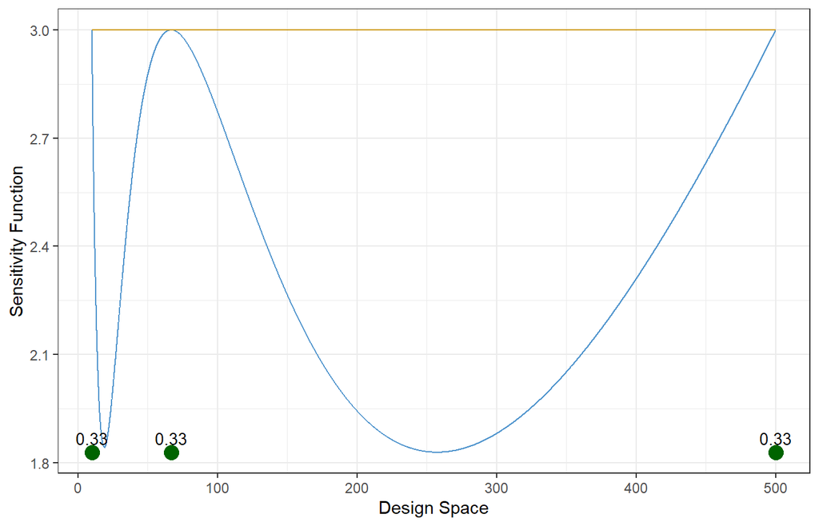

```r
plot(result_tait1)
```

```r
eff_paper1 <- design_efficiency(
  data.frame(Point=c(10,66.5,500), Weight=rep(1/3,3)), result_tait1)
cat("Eficiencia diseño paper:", round(eff_paper1*100,2), "%\n")
```

```
## Eficiencia diseño paper: 100 %
```

```r
# Réplica de la Table 1 (columna k=1) del paper
cat("\nEficiencias de diseños uniformes:\n")
```

```
##
## Eficiencias de diseños uniformes:
```

```r
sapply(3:10, function(np) {
  des <- data.frame(Point=seq(10,500,l=np), Weight=rep(1/np,np))
  round(suppressMessages(design_efficiency(des,result_tait1))*100, 2)
}) |> setNames(paste0(3:10,"pts")) |> print()
```

```
##  3pts  4pts  5pts  6pts  7pts  8pts  9pts 10pts
## 63.45 70.34 71.45 70.68 69.26 67.64 66.02 64.46
```

## 6.2 Tait no-isoterma — 1-feniludecano (2D, $k=8$)

$\rho_0(T) = A_0+A_1T+A_2T^2+A_3T^3$, $B(T)=B_0+B_1T+B_2T^2$, $C$ constante. Espacio $p \in [0.1, 65]$ MPa, $T \in [293.15, 353.15]$ K. Paper: 11 puntos; eficiencia del diseño experimental ($14\times7$): 62.37%.

```r
result_tait2 <- opt_des(
  criterion    = "D-Optimality",
  model        = y ~ (A0+A1*x2+A2*x2^2+A3*x2^3) *
                     (1-C*log((B0+B1*x2+B2*x2^2+x1)/(B0+B1*x2+B2*x2^2+0.1))),
  parameters   = c("A0","A1","A2","A3","B0","B1","B2","C"),
  par_values   = c(0.97877,-7.8964e-7,-1.9601e-6,1.8159e-9,
                   480.83,-1.6932,1.6652e-3,0.087944),
  design_space = list(x1=c(0.1,65), x2=c(293.15,353.15))
)
cat("Puntos:", nrow(result_tait2$optdes), "(paper: 11) | Atwood:",
    result_tait2$atwood, "%\n")
```

```
## Puntos: 11 (paper: 11) | Atwood: 99.91732 %
```

```r
result_tait2$optdes
```

| x1 | x2 | Weight |
| --- | --- | --- |
| 0.10000 | 335.3622 | 0.0962782 |
| 0.10000 | 353.1500 | 0.1179262 |
| 0.10000 | 293.1500 | 0.1207722 |
| 0.10000 | 311.6436 | 0.0788637 |
| 27.06481 | 353.1016 | 0.0757296 |
| 27.39823 | 339.0605 | 0.0638940 |
| 27.79575 | 308.7335 | 0.0500257 |
| 64.88900 | 333.6526 | 0.0940394 |
| 65.00000 | 293.1500 | 0.1199241 |
| 65.00000 | 353.1500 | 0.1158684 |
| 65.00000 | 311.3297 | 0.0666786 |

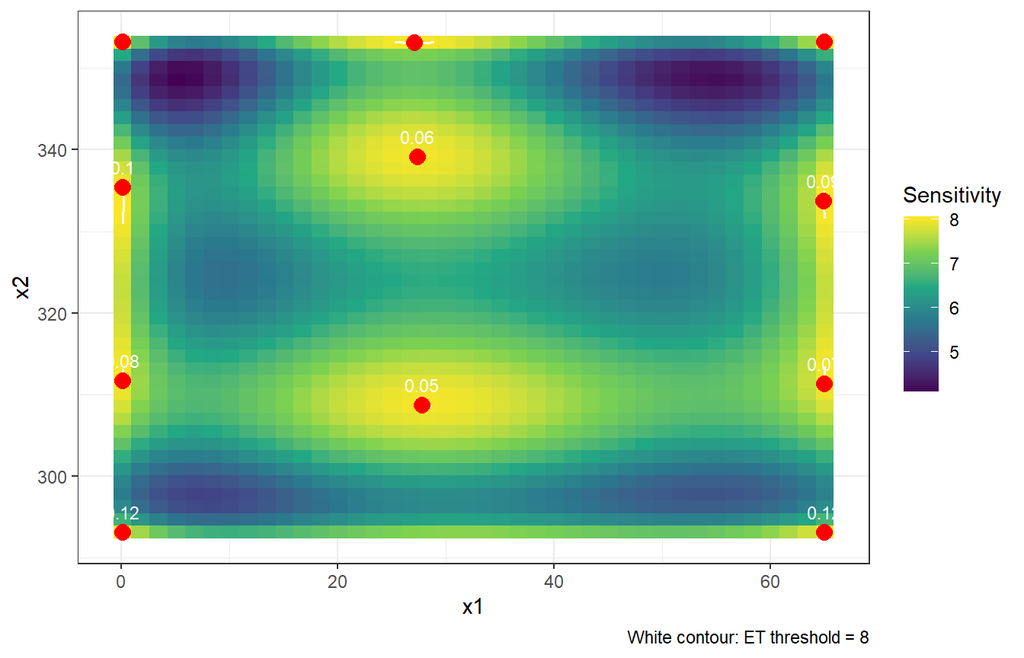

```r
plot(result_tait2)
```

```r
design_exp2 <- expand.grid(x1=seq(0.1,65,l=14), x2=seq(293.15,353.15,l=7))
design_exp2$Weight <- rep(1/nrow(design_exp2), nrow(design_exp2))
eff2 <- design_efficiency(design_exp2, result_tait2)
cat("Eficiencia 14x7:", round(eff2*100,2), "% (paper: 62.37%)\n")
```

```
## Eficiencia 14x7: 62.36 % (paper: 62.37%)
```

## 6.3 Tait-Rackett — JP-10 (2D, $k=8$)

$\rho_0(T) = A_R / B_R^{1+(1-T/C_R)^{D_R}}$ (ecuación de Rackett). Espacio $p \in [0.083, 30]$ MPa, $T \in [270, 470]$ K. Con rangos muy distintos (30 MPa vs 200 K) el `join_thresh` automático $\min(\text{rangos})/10 \approx 3$ es crítico para la convergencia. Paper: 10 puntos; eficiencia del diseño experimental ($12\times11$): 55.34%.

```r
result_tait3 <- opt_des(
  criterion    = "D-Optimality",
  model        = y ~ (AR/BR^(1+(1-x2/CR)^DR)) *
                     (1-C*log((B0+B1*x2+B2*x2^2+x1)/(B0+B1*x2+B2*x2^2+0.083))),
  parameters   = c("AR","BR","CR","DR","B0","B1","B2","C"),
  par_values   = c(293.822,0.504584,621.385,0.574121,
                   417.1,-1.35603,1.15586e-3,79.1823e-3),
  design_space = list(x1=c(0.083,30), x2=c(270,470))
)
cat("Puntos:", nrow(result_tait3$optdes), "(paper: 10) | Atwood:",
    result_tait3$atwood, "%\n")
```

```
## Puntos: 10 (paper: 10) | Atwood: 88.49896 %
```

```r
result_tait3$optdes
```

| x1 | x2 | Weight |
| --- | --- | --- |
| 0.08300 | 470.0000 | 0.1238638 |
| 0.08300 | 428.1647 | 0.1100647 |
| 0.08300 | 270.0000 | 0.1163422 |
| 0.08300 | 350.9947 | 0.0827112 |
| 12.73646 | 470.0000 | 0.1132416 |
| 12.87082 | 438.7672 | 0.0286879 |
| 28.61456 | 327.7597 | 0.0780096 |
| 30.00000 | 470.0000 | 0.1239637 |
| 30.00000 | 270.0000 | 0.1085777 |
| 30.00000 | 415.5560 | 0.1145377 |

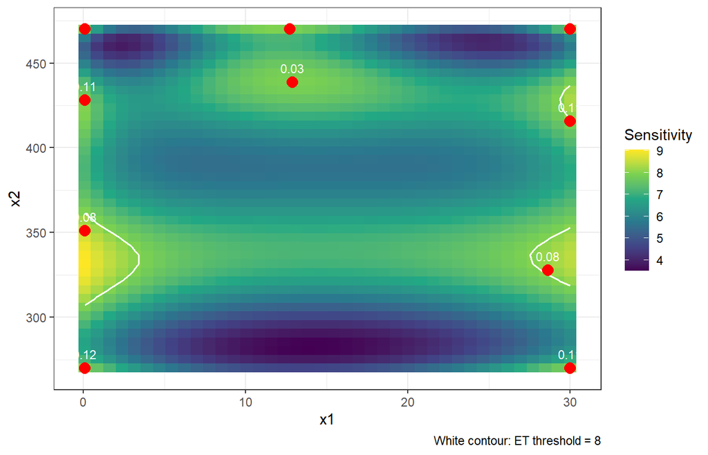

```r
plot(result_tait3)
```

```r
design_exp3 <- expand.grid(x1=seq(0.083,30,l=12), x2=seq(270,470,l=11))
design_exp3$Weight <- rep(1/nrow(design_exp3), nrow(design_exp3))
eff3 <- design_efficiency(design_exp3, result_tait3)
cat("Eficiencia 12x11:", round(eff3*100,2), "% (paper: 55.34%)\n")
```

```
## Eficiencia 12x11: 53.63 % (paper: 55.34%)
```